# Visualise participants against model predictions for stability parameter 0.98

2024-10-10

This code visualises combined participant and model predictions at stability parameter 0.98.

## Correlation between participants and cesm (rough model fit) drawing out different groupings

This series of scatter plots is for all three probability settings, for just this value of s, 0.98. In order we draw out several different variables that might help partition the graph. It’s the same chart every time, only with a different variable colour split.

All are at sensitivity 1 (i.e. the normal probabilities, same as participants saw).

**The colour grouping here is for ‘bare’ variable type, observed (A and B) and unobserved (Au and Bu)**

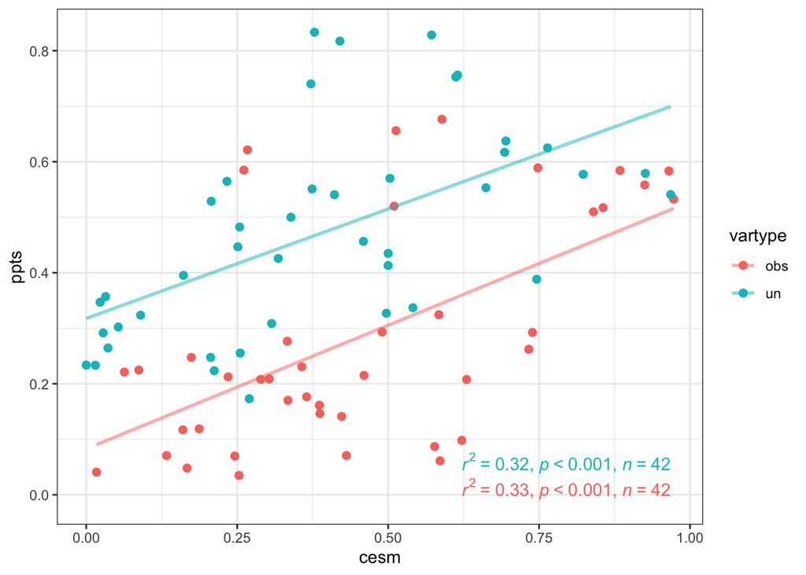

It looks like participants rate the unobserved variables higher than the model does.

Next, colour grouping here for ‘real’ Latent variable

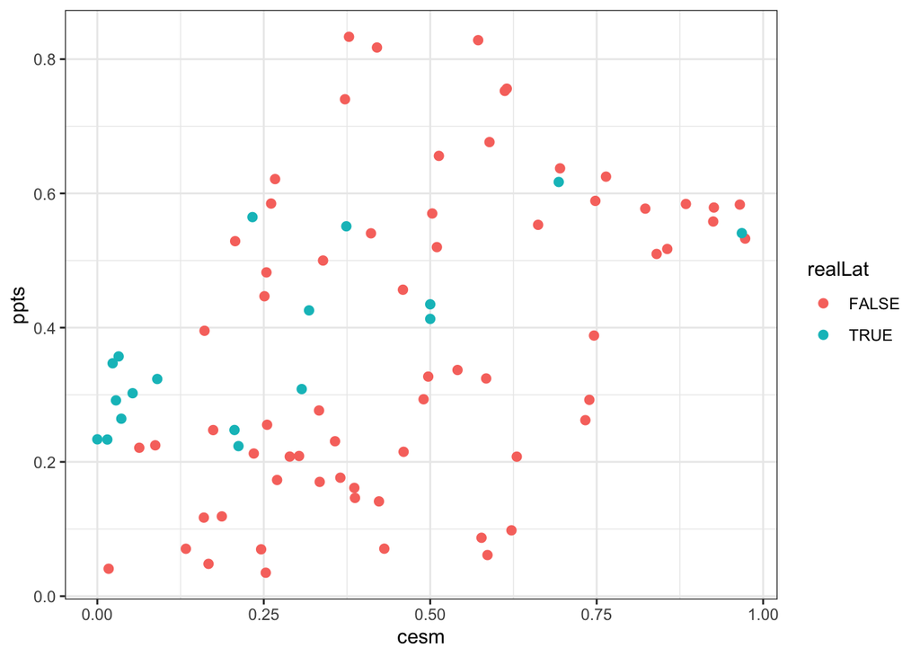

The colour grouping here is for structure

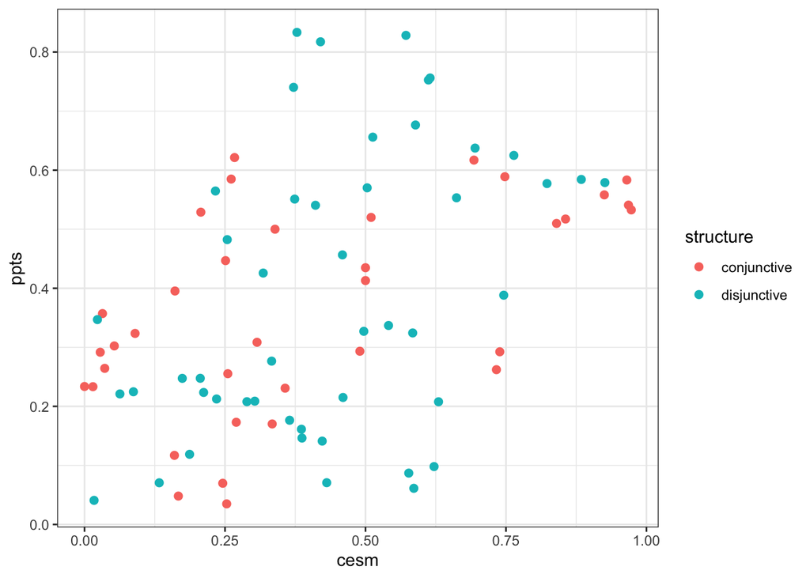

and trialtype

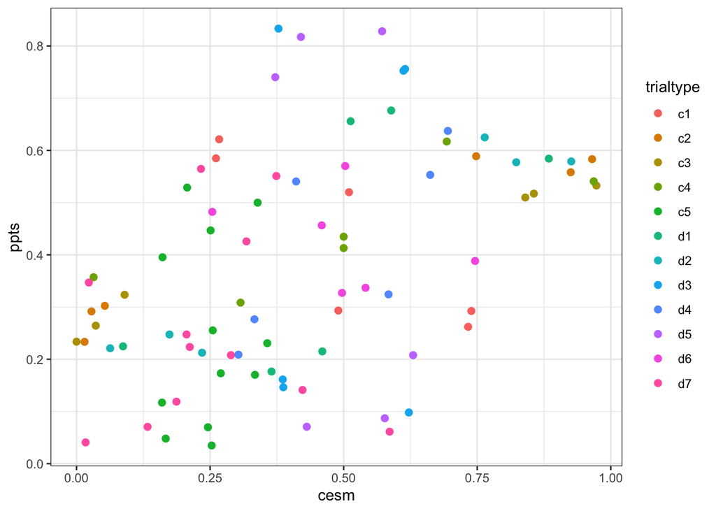

But after all that, it seems the best distinguisher is whether or not the effect actually occurred!

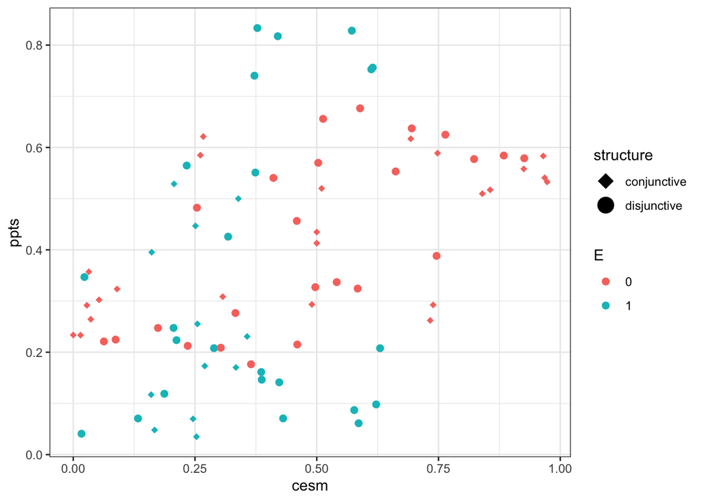

So to put it all together, maybe the best dissociation is in vartype and Effect: people pick unobserved variables when the Effect happens.

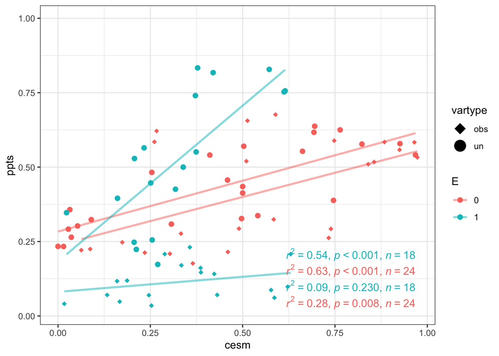

### A new variable called ‘everything happens’ (a1)

This one shows a cluster of observed vars are chosen as LOW by people when everything happens

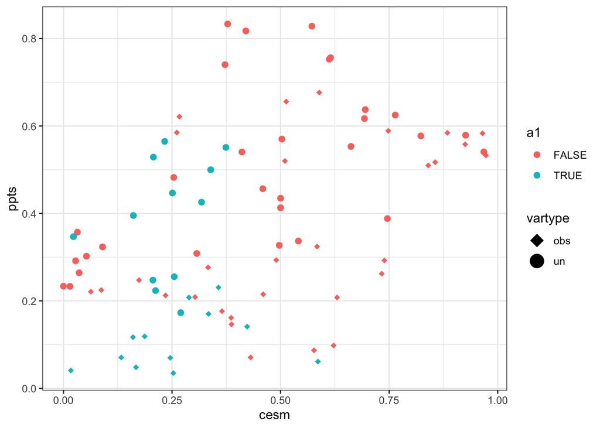

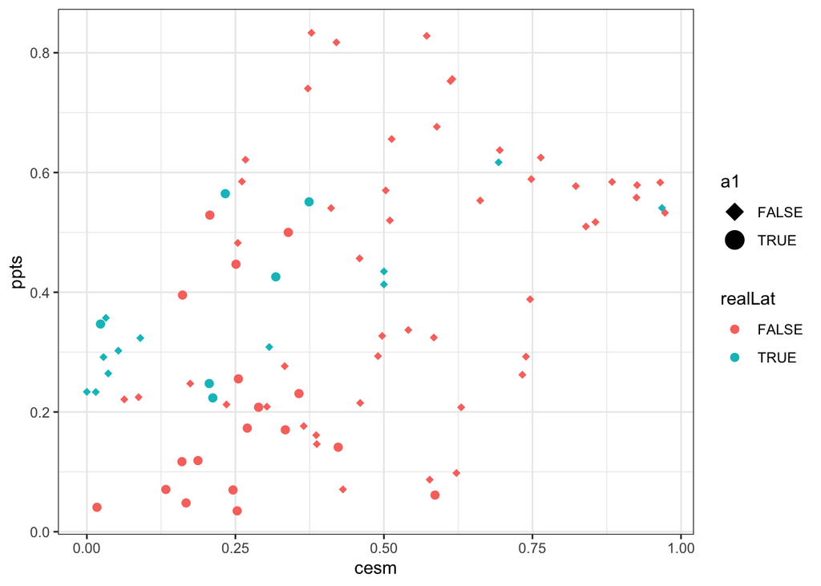

## Model predictions compared against participant data, split out by probability group

These three plots show dotted line for baseline, if considering permissable variables. (But we decided not to use that, so unclear at Jan25 if this has repercussions downstream. If not, these charts are just useful for historical record).

The first plot is probability group 1.

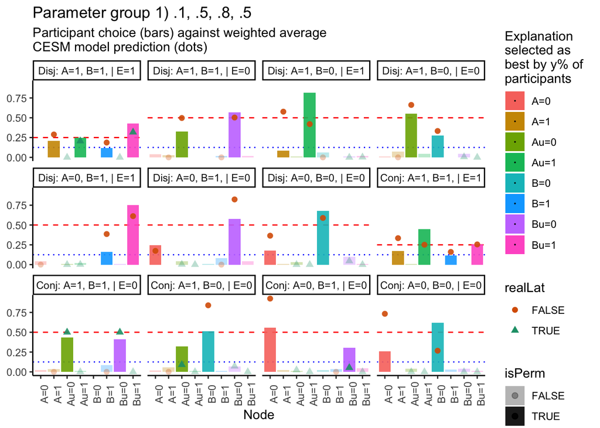

The second is probability group 2.

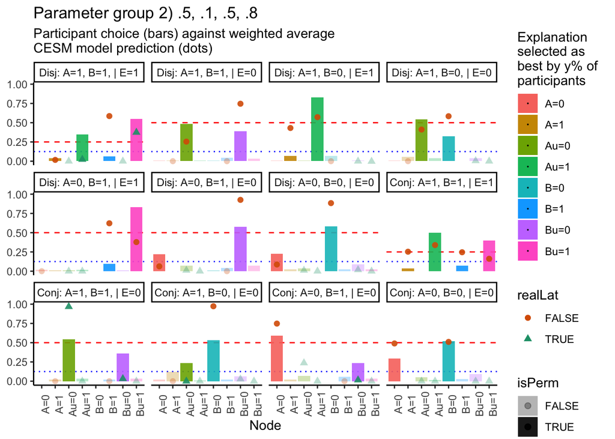

Now for probability group 3.

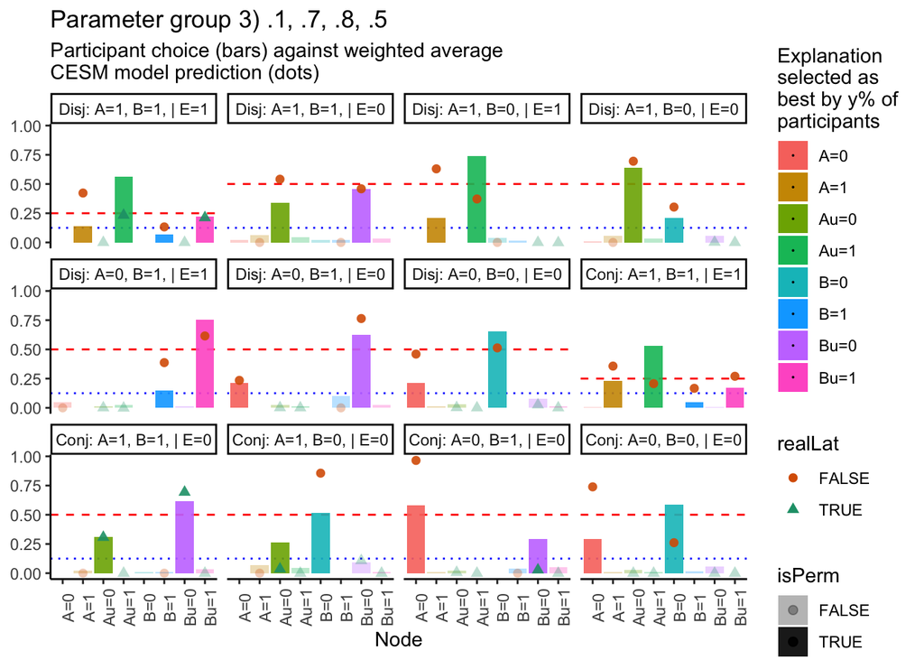

## NEW section for bringing in sensitivity

We also looked at ‘sensitivity’ to the probability manipulation, as a parameter scaled between 0 (a model where all four variables has probability 0.5) and 1 (they had their probabilities).

These correlations can be visualised in a matrix, to quickly see what the best combo of stab and sens is, in the file `lesions_and_NLL.Rmd`.

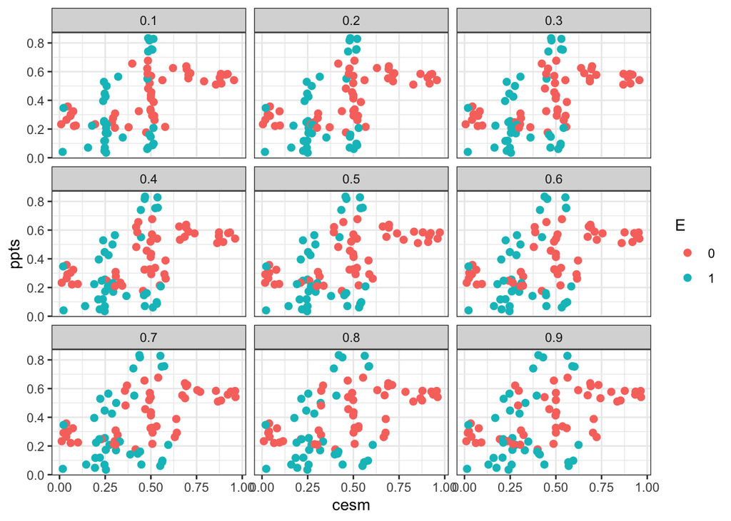

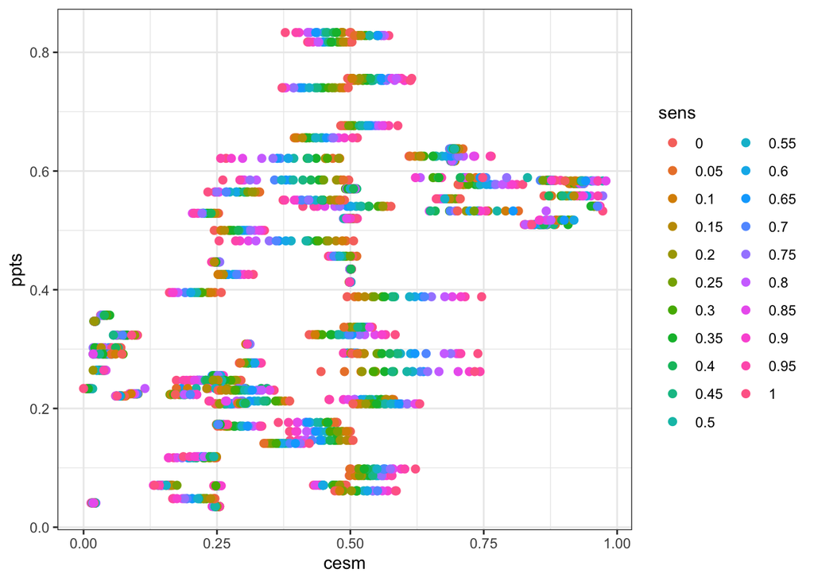

The overall model fit correlation is 0.489.

**Tadeg’s suggestion:** Compute model fit separately for unobserved and observed variables. I.e. since a lot of the model failing resides in not accounting for people’s relative preference for unobserved variables, how much can it account for people’s judgments within unobserved variables. And within observed variables.